```r
knitr::opts_chunk$set(echo = TRUE, warning = FALSE, message = FALSE)

library(ggplot2)
#library(cowplot)
library(ggbeeswarm)
#library(ggpubr)
library(dplyr)
#library(kableExtra)
library(tidyr)
library(ggtree)
library(phytools)
library(phangorn)
library(reshape2)
library(ggExtra)
library(ggrepel)
library(vroom)
#source("../lib/design.r")
source("C:/bin/core/corelib/design.r")
source("C:/bin/core/get_tree_info.r")

htmltools::includeHTML("../html-chunks/rmd_nav.html")
```

# Full coding species tree

```r
tree_type = "concat"
save_tree_fig = F

if(tree_type == "astral"){
  cat("188 species.\n11,775 coding loci.\nGene trees inferred with IQtree.\nSpecies tree inferred with ASTRAL (no branch lengths shown).\n")
}else if(tree_type == "concat"){
  cat("188 species.\n11,775 coding loci.\nGene trees inferred with IQtree.\nSpecies tree inferred with by concatenation of all loci with IQtree.\n")
}
```

```
## 188 species.
## 11,775 coding loci.
## Gene trees inferred with IQtree.
## Species tree inferred with by concatenation of all loci with IQtree.
```

```r
tree_file = "../../data/trees/full_coding_iqtree_astral.cf.rooted.tree"
astral_tree = read.tree(tree_file)

tree_info_astral = treeToDF(astral_tree)
tree_info_astral = tree_info_astral %>% separate(label, c("astral", "gcf", "scf"), sep="/", remove=F)
tree_info_astral$astral[tree_info_astral$node.type=="tip"] = NA
tree_info_astral$astral = as.numeric(tree_info_astral$astral)
tree_info_astral$gcf = as.numeric(tree_info_astral$gcf)
tree_info_astral$scf = as.numeric(tree_info_astral$scf)
# Read astral tree data

concat_file = "../../data/trees/full_coding_iqtree_concat.cf.rooted.tree"
concat_tree = read.tree(concat_file)

tree_info_concat = treeToDF(concat_tree)
tree_info_concat = tree_info_concat %>% separate(label, c("bootstrap", "gcf", "scf"), sep="/", remove=F)
tree_info_concat$bootstrap[tree_info_concat$node.type=="tip"] = NA
tree_info_concat$bootstrap = as.numeric(tree_info_concat$bootstrap)
tree_info_concat$gcf = as.numeric(tree_info_concat$gcf)
tree_info_concat$scf = as.numeric(tree_info_concat$scf)
# Read concat tree data

rf = RF.dist(concat_tree, astral_tree)
nrf = RF.dist(concat_tree, astral_tree, normalize=T)

#treecomp = comparePhylo(concat_tree, astral_tree, plot=T)
# Stores node ids of common clades between trees!

#write.csv(tree_info, "../../data/trees/full-coding-concat-cf-rooted.csv", row.names=F)

if(tree_type == "astral"){
  tree_info = tree_info_astral
  rodent_tree = astral_tree
  xmax = 31
}else if(tree_type == "concat"){
  tree_info = tree_info_concat
  rodent_tree = concat_tree
  xmax = 0.125
}
```

### Species tree with branches colored by gene concordance factor

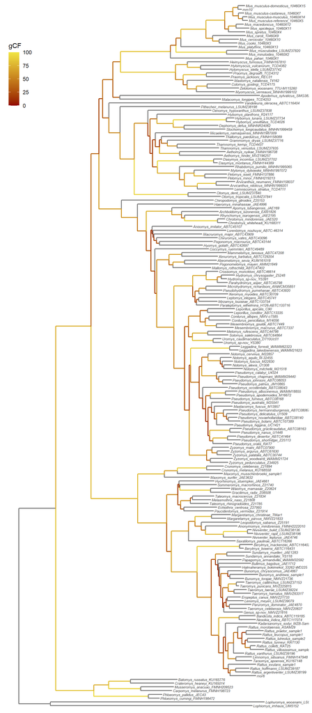

```r
h = corecol(numcol=1, pal="wilke", offset=3)
l = corecol(numcol=1, offset=3)
# Colors

gcf_tree = ggtree(rodent_tree, size=0.8, ladderize=F, aes(color=tree_info$gcf)) +
  scale_color_continuous(name='gCF', low=l, high=h, limits=c(0,100)) +
  xlim(0, xmax) +
  geom_tiplab(color="#333333", fontface='italic', size=2) +
  theme(legend.position=c(0.05,0.9))
print(gcf_tree)
```

```r
if(save_tree_fig){
  gcf_tree = gcf_tree + geom_text(aes(x=branch, label=ifelse(tree_info$node.type=="internal",as.character(node), ''), label.size=NA, fill="transparent"), size=2, vjust=-0.2)
  tree_outfile = paste("../../data/trees/", tree_type, "-gcf-tree.pdf", sep="")
  ggsave(tree_outfile, gcf_tree, width=8, height=16, unit="in")
}
# gCF tree
```

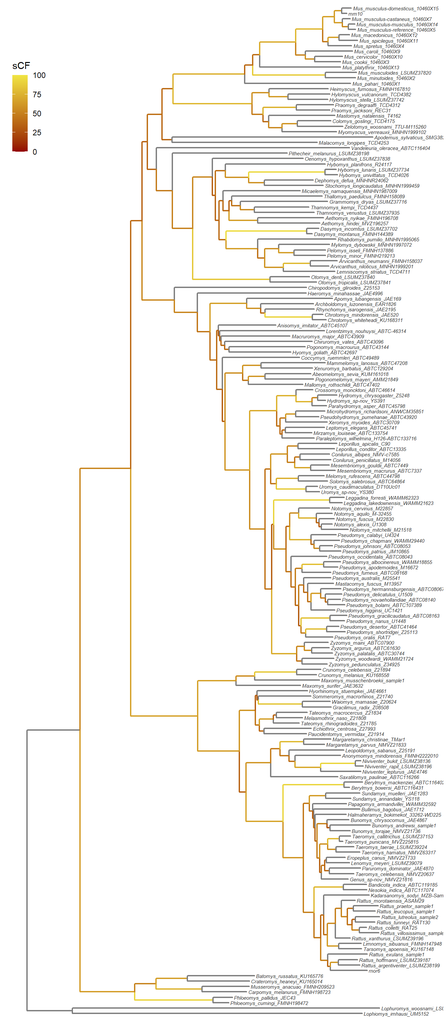

```r
h = corecol(numcol=1, pal="wilke", offset=3)
l = corecol(numcol=1, offset=3)
# Colors

scf_tree = ggtree(rodent_tree, size=0.8, ladderize=F, aes(color=tree_info$scf)) +
  scale_color_continuous(name='sCF', low=l, high=h, limits=c(0,100)) +
  xlim(0, xmax) +
  geom_tiplab(color="#333333", fontface='italic', size=2) +
  theme(legend.position=c(0.05,0.9))
#geom_text(aes(label=rodent_data$support), hjust=-.1, color="#006ddb") +
#geom_nodepoint(color="#666666", alpha=0.85, size=4)
print(scf_tree)
```

```r
#ggsave("../data/trees/scf-tree.pdf", scf_tree, width=8, height=16, unit="in")
# sCF tree
```

### Gene vs. site concordance factors colored by branch support

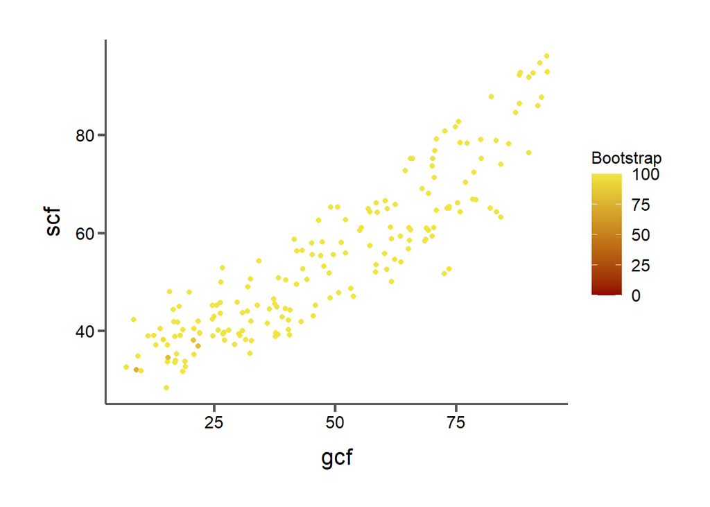

```r
h = corecol(numcol=1, pal="wilke", offset=3)
l = corecol(numcol=1, offset=3)
# Colors

if(tree_type == "astral"){
  p = ggplot(tree_info, aes(x=gcf, y=scf, color=astral)) +
    geom_point() +
    scale_color_continuous(name='Astral support', low=l, high=h, limits=c(0.8,1))
}else if(tree_type == "concat"){
  p = ggplot(tree_info, aes(x=gcf, y=scf, color=bootstrap)) +
    geom_point() +
    scale_color_continuous(name='Bootstrap', low=l, high=h, limits=c(0,100))
}
p = p + bartheme() +
  theme(legend.title=element_text(size=12))
print(p)
```

# Average rates per gene with basic model fit (mg94-local)

We ran each of the 11,775 coding loci through [HyPhy’s standard MG94 fit](https://github.com/veg/hyphy-analyses/tree/master/FitMG94) with the `-local` option to estimate a rate for each branch in the input tree.

For input trees we used the gene tree estimated from each individual alignment to reduce false inferences of substitutions that result from tree misspecification.

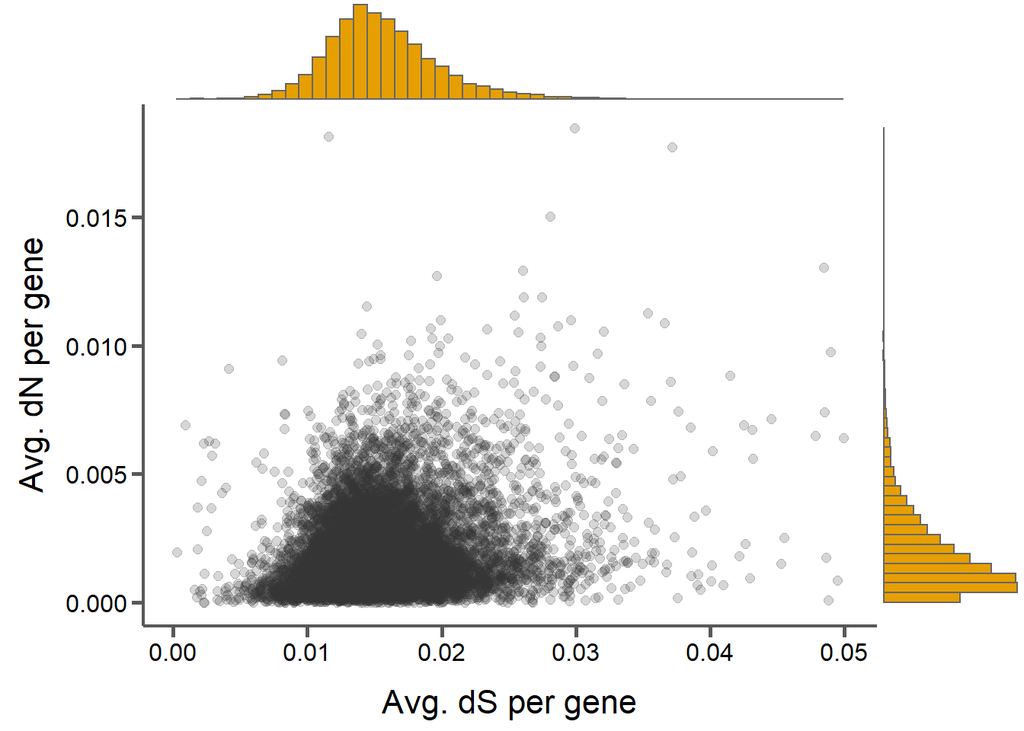

```r
mg94_local_file_gz = gzfile("../../data/rates/full-coding-mg94-local.csv.gz")
mg94_local = vroom(mg94_local_file_gz, comment="#")

mg94_local_gene = group_by(mg94_local, file) %>% summarize(dn=mean(dn, na.rm=T), ds=mean(ds, na.rm=T), dn.ds=mean("dn/ds", na.rm=T), nonsynonymous.bl=mean("nonsynonymous bl", na.rm=T), synonymous.bl=mean("synonymous bl", na.rm=T))

p = ggplot(subset(mg94_local_gene, ds < 0.05), aes(x=ds, y=dn)) +
  geom_point(size=2, alpha=0.2, color="#333333") +
  #geom_smooth(method="lm", se=F, ) +
  xlab("Avg. dS per gene") +
  ylab("Avg. dN per gene") +
  bartheme()
p = ggExtra::ggMarginal(p, type="histogram", bins=50, fill=corecol(pal="wilke", numcol=1), color="#666666")
print(p)
```

```r
ds_p = ggplot(subset(mg94_local_gene, ds < 0.05), aes(x=ds)) +
  geom_histogram(bins=50, fill=corecol(pal="wilke", numcol=1), color="#666666") +
  scale_y_continuous(expand=c(0,0)) +
  xlab("dS") +
  ylab("# of genes") +
  bartheme()
print(ds_p)
# Distribution of dS when using concatenated tree
```

[output not shown]

```r
dn_p = ggplot(mg94_local_gene, aes(x=dn)) +
  geom_histogram(bins=50, fill=corecol(pal="wilke", numcol=1), color="#666666") +
  scale_y_continuous(expand=c(0,0)) +
  xlab("dN") +
  ylab("# of genes") +
  bartheme()
print(dn_p)
# Distribution of dS when using gene trees
```

[output not shown]

```r
ds_filter_level = 0.03

ds_filter = subset(mg94_local_gene, ds > ds_filter_level)$file
# Get a list of genes to filter out in subsequent analyses based on dS

print(paste("Removing", length(ds_filter), "genes with dS above", ds_filter_level, "from subsequent analyses."))
```

```
## [1] "Removing 183 genes with dS above 0.03 from subsequent analyses."
```

```r
#write.csv(ds_filter, file="../../data/rates/mg94-local-ds-filter-0.03.csv", row.names=F)
```

# Average rates per branch with basic model fit (mg94-local)

Because we used the gene trees, in order to quantify rates on species tree branches we first needed to check whether branches in the species tree exist in a given gene tree.

This resulted in three categories for a species tree branch in a given gene tree:

1. Full clade: All species in the clade that descends from the branch in the species tree are present as a monophyletic split in the gene tree.
2. Parital clade: Not all species in the clade that descends from the branch in the species tree are present in the gene tree, but the ones that are present form a monophyletic split.
3. Discordant/missing clade: Either the species in the clade that descends from the branch in the species tree do not form a monophyletic split in this gene tree (discordant) or ALL species in this clade are missing from this gene tree (missing)

Average rates are then calculated as (for dS, for example):

$$\frac{\sum_{i=1}^{n}\text{branch dS}_i}{n}$$

Where:

- $n = \text{# full clade genes} + \text{# partial clade genes}$ for this branch

### Species tree branch presence/absence per gene

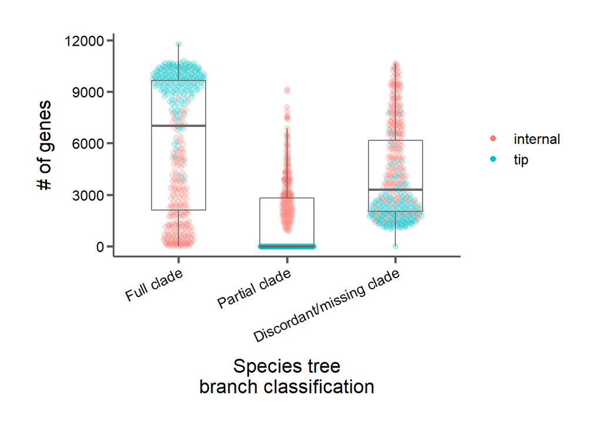

```r
if(tree_type == "astral"){
  tree_rates = read.csv("../../data/rates/full-coding-astral-cf-rooted-rates.csv", header=T)
}else if(tree_type == "concat"){
  tree_rates = read.csv("../../data/rates/full-coding-concat-cf-rooted-rates.csv", header=T)
}
# Read the branch average rate data

full_clade = select(tree_rates, clade, node.type, num.genes.full)
full_clade$label = "Full clade"
names(full_clade)[3] = "num.genes"

partial_clade = select(tree_rates, clade, node.type, num.genes.partial)
partial_clade$label = "Partial clade"
names(partial_clade)[3] = "num.genes"

no_clade = select(tree_rates, clade, node.type, num.genes.no.clade)
no_clade$label = "Discordant/missing clade"
names(no_clade)[3] = "num.genes"

clade_counts = rbind(full_clade, partial_clade, no_clade)
# Convert branch categories to long format

clade_counts$label = factor(clade_counts$label, levels=c("Full clade", "Partial clade", "Discordant/missing clade"))

branch_counts = ggplot(clade_counts, aes(x=label, y=num.genes, group=label, color=node.type)) +
  geom_quasirandom(size=2, width=0.25, alpha=0.25) +
  geom_boxplot(outlier.shape=NA, alpha=0.15, width=0.5, color="#666666") +
  ylab("# of genes") +
  xlab("Species tree\nbranch classification") +
  bartheme() +
  theme(axis.text.x = element_text(angle=25, hjust=1)) +
  guides(colour=guide_legend(override.aes=list(alpha=1)))
print(branch_counts)
```

These measures are highly correlated with gene concordance factors:

### Correlation between gCF and the % of genes that contain the descending clade for each species tree branch

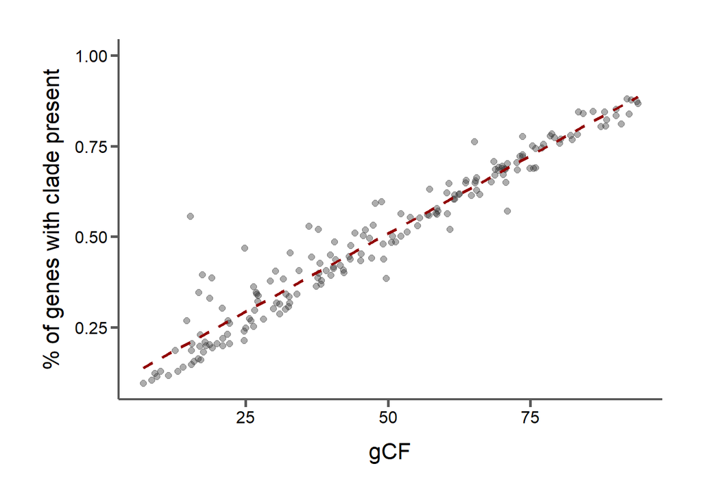

```r
tree_rates$clade.perc = (tree_rates$num.genes.full + tree_rates$num.genes.partial) / (tree_rates$num.genes.full + tree_rates$num.genes.partial + tree_rates$num.genes.no.clade)


p = ggplot(tree_rates, aes(x=gcf, y=clade.perc)) +
  geom_point(size=2, alpha=0.4, color="#333333") +
  geom_smooth(method="lm", se=F, linetype="dashed", color="#920000") +
  xlab("gCF") +
  ylab("% of genes with clade present") +
  bartheme() +
  theme(legend.position="none")
print(p)
```

### This results in the following distributions for average rates across branches:

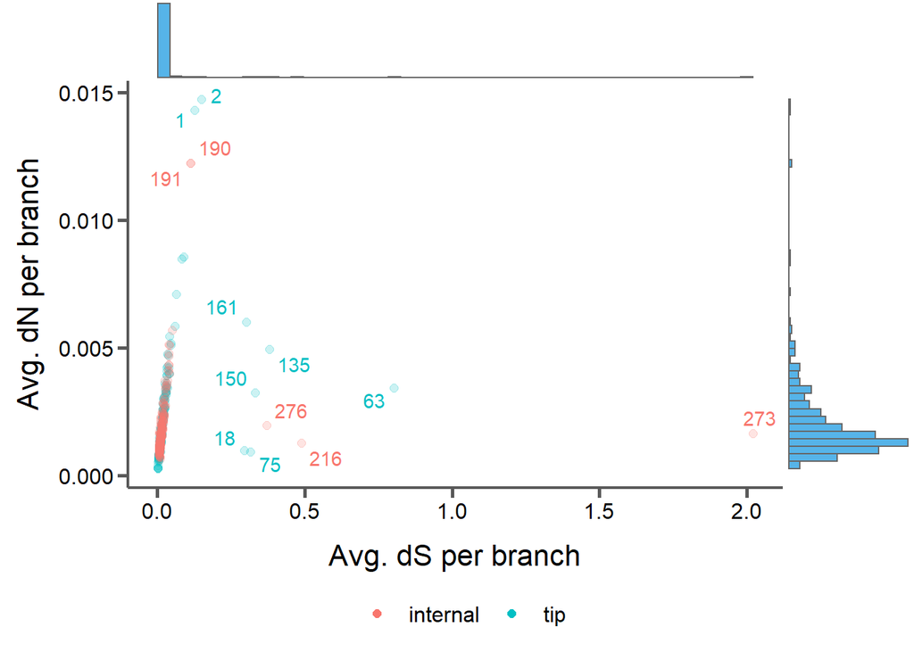

```r
p = ggplot(subset(tree_rates, node.type!="ROOT"), aes(x=avg.ds, y=avg.dn, color=node.type)) +
  geom_point(size=2, alpha=0.2) +
  geom_text_repel(aes(label=ifelse(avg.ds>0.2|avg.dn>0.01,as.character(node),'')), show_guide=F) +
  #geom_smooth(method="lm", se=F, ) +
  xlab("Avg. dS per branch") +
  ylab("Avg. dN per branch") +
  bartheme() +
  theme(legend.position="bottom") +
  guides(colour = guide_legend(override.aes = list(alpha = 1)))
p = ggExtra::ggMarginal(p, type="histogram", bins=50, fill=corecol(pal="wilke", numcol=1, offset=1), color="#666666")
print(p)
```

```r
tree_rates$ds.outlier = ifelse(tree_rates$avg.ds>0.2,tree_rates$node,'')
tree_rates$dn.outlier = ifelse(tree_rates$avg.dn>0.01,tree_rates$node,'')
```

### The tree with branches colored by dS and outliers labeled:

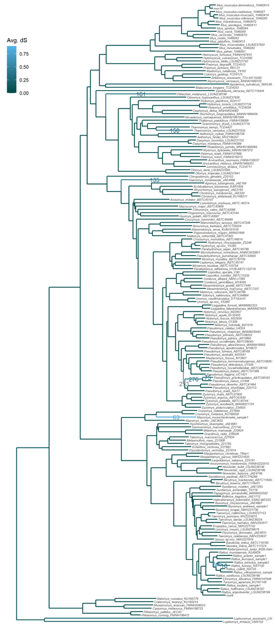

```r
h = corecol(numcol=1, pal="wilke", offset=1)
l = corecol(numcol=1, offset=1)

rate_tree = ggtree(rodent_tree, size=0.8, ladderize=F, aes(color=tree_rates$avg.ds)) +
  scale_color_continuous(name='Avg. dS', low=l, high=h, limits=c(0,0.9)) +
  xlim(0, xmax) +
  geom_tiplab(color="#333333", fontface='italic', size=2) +
  theme(legend.position=c(0.05,0.9)) +
  geom_label(aes(x=branch, label=ifelse(tree_rates$avg.ds>0.2,as.character(node),'')), label.size=NA, fill="transparent")
  #geom_text(aes(label=node), hjust=-.1, color="#006ddb")
#geom_nodepoint(color="#666666", alpha=0.85, size=4)
print(rate_tree)
```

### The tree with branches colored by dN and outliers labeled:

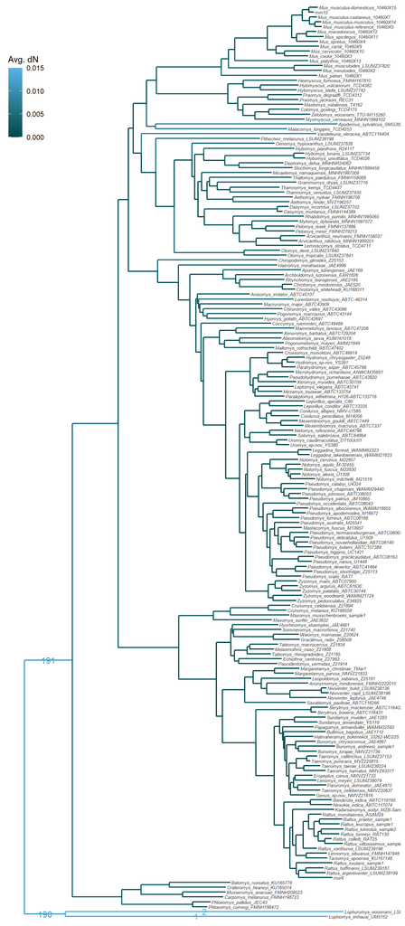

```r
h = corecol(numcol=1, pal="wilke", offset=1)
l = corecol(numcol=1, offset=1)

rate_tree = ggtree(rodent_tree, size=0.8, ladderize=F, aes(color=tree_rates$avg.dn)) +
  scale_color_continuous(name='Avg. dN', low=l, high=h, limits=c(0,0.015)) +
  xlim(0, xmax) +
  geom_tiplab(color="#333333", fontface='italic', size=2) +
  theme(legend.position=c(0.05,0.9)) +
  geom_label(aes(x=branch, label=ifelse(tree_rates$avg.dn>0.01,as.character(node),'')), label.size=NA, fill="transparent")
#geom_text(aes(label=rodent_data$support), hjust=-.1, color="#006ddb") +
#geom_nodepoint(color="#666666", alpha=0.85, size=4)
print(rate_tree)
```

# Basic rate and phenotype correlations with tip branches

```r
pheno = read.csv("../../data/phenotype-data/combined-phenotype-data.csv", header=T, comment.char="#")
tips = subset(tree_rates, node.type=="tip")
names(tips)[2] = "sample"
pheno_rates = merge(pheno, tips, by="sample")

pheno_rates = select(pheno_rates, sample, Adult_Mass.g., Total_Length.mm., Head.Body_Length.mm., Tail_Length.mm., Hind_Foot_Length.mm., Relative_Tail_Length, Relative_Hind_Foot_Length, avg.dn, avg.ds, avg.dn.ds)

pheno_rates_long = melt(pheno_rates, id.vars=c("sample", "avg.dn", "avg.ds", "avg.dn.ds"))

#pheno_rates_long = gather(pheno_rates, sample, value, Adult_Mass.g., Total_Length.mm., Head.Body_Length.mm., Tail_Length.mm., Hind_Foot_Length.mm., Relative_Tail_Length, Relative_Hind_Foot_Length)
```

### Avg. dS per tip vs phenotype

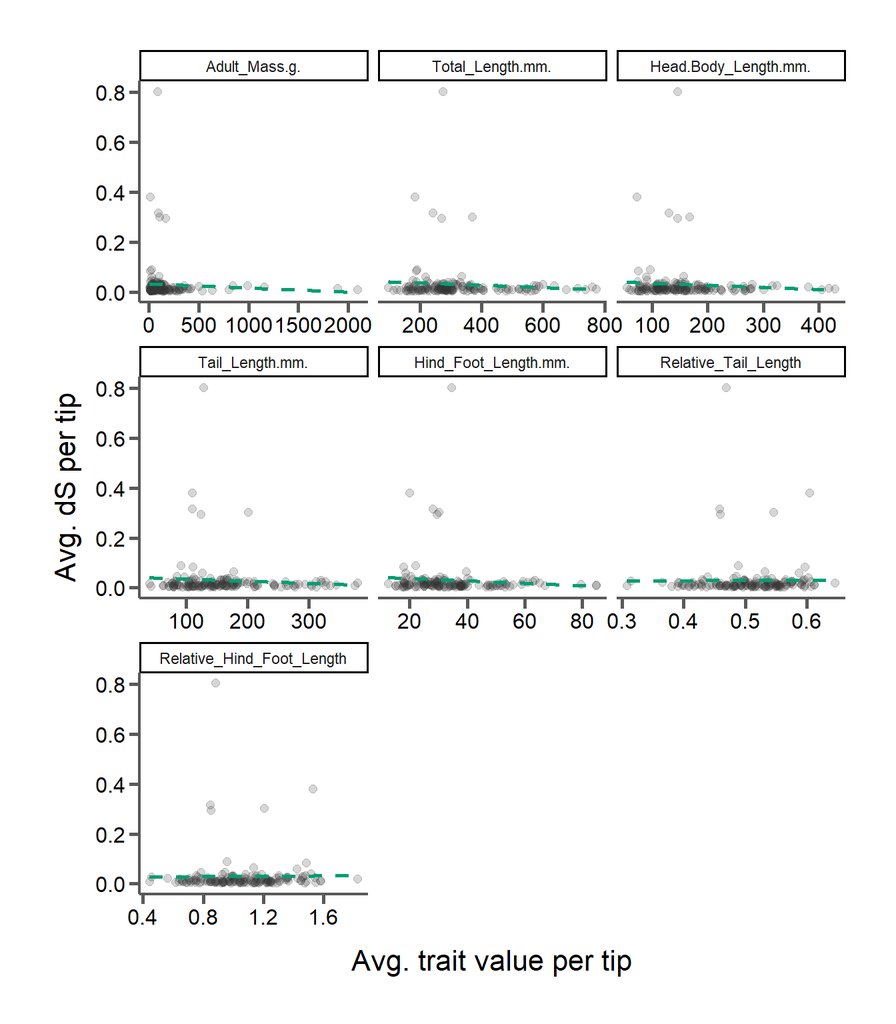

```r
p = ggplot(pheno_rates_long, aes(x=value, y=avg.ds)) +
  geom_point(size=2, alpha=0.2, color="#333333") +
  geom_smooth(method="lm", se=F, linetype="dashed", color=corecol(numcol=1, pal="wilke", offset=2)) +
  xlab("Avg. trait value per tip") +
  ylab("Avg. dS per tip") +
  facet_wrap(~variable, scales="free_x") +
  bartheme()
print(p)
```

### Avg. dN per tip vs phenotype

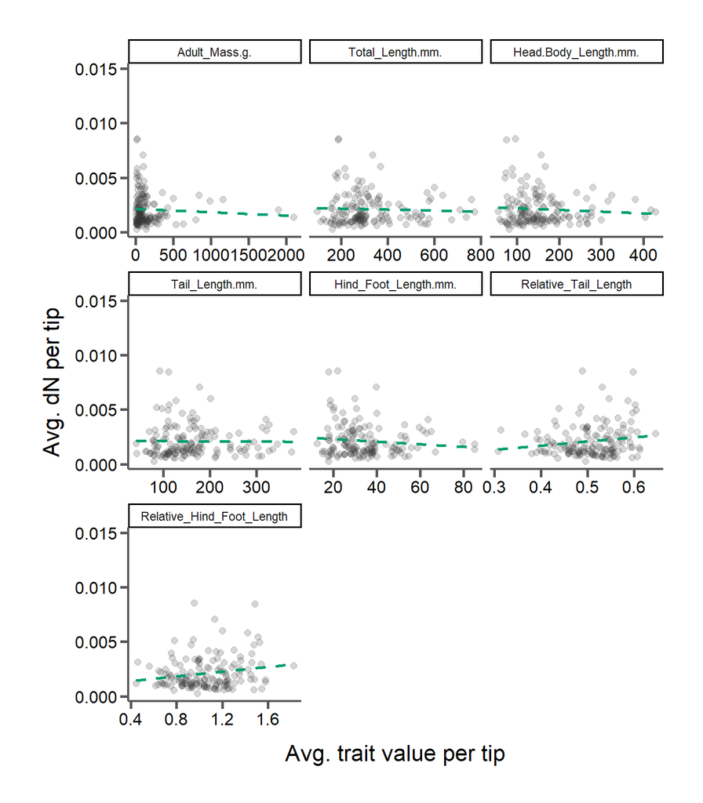

```r
p = ggplot(pheno_rates_long, aes(x=value, y=avg.dn)) +
  geom_point(size=2, alpha=0.2, color="#333333") +
  geom_smooth(method="lm", se=F, linetype="dashed", color=corecol(numcol=1, pal="wilke", offset=2)) +
  xlab("Avg. trait value per tip") +
  ylab("Avg. dN per tip") +
  facet_wrap(~variable, scales="free_x") +
  bartheme()
print(p)
```

```r
cat("Page last updated:", format(Sys.time(), "%m/%d/%Y %H:%M:%S %Z"))
```

```
## Page last updated: 07/01/2021 23:17:56 MDT
```

```r
htmltools::includeHTML("../html-chunks/rmd_footer.html")
```